# NLP_Assignment3_SwathiGanesan

## NLP Class Assignment 3

```python
import pandas as pd
import numpy as np
import re
import nltk
from nltk.tokenize import word_tokenize
import matplotlib.pyplot as plt
from nltk.corpus import stopwords
from nltk.stem import PorterStemmer
from sklearn.feature_extraction.text import CountVectorizer
from scipy.spatial.distance import pdist, squareform

pd.set_option('display.max_rows', 100)
pd.set_option('display.max_columns', None)
pd.set_option('display.max_colwidth', 500)
```

#### Read news data

```python
news_path = 'https://storage.googleapis.com/msca-bdp-data-open/news/nlp_a_3_news.json'
news_df = pd.read_json(news_path, orient='records', lines=True)

print(f'Sample contains {news_df.shape[0]:,.0f} news articles')
news_df.head(2)
```

```
Sample contains 1,018 news articles
```

|  | url | date | language | title | text |
| --- | --- | --- | --- | --- | --- |
| 0 | https://auto.hindustantimes.com/lml-bikes/dealers/bodh-gaya | 2022-01-21 | en | Lml Bikes Car Dealers - Lml Bikes Showrooms in India | Lml Bikes Car Dealers - Lml Bikes Showrooms in India Explore Friday, 21 January 2022 Log in/Sign up SearchNotificationsTop SectionsAuto NewsCar NewsBike NewsLatestAuto NewsPhotosVideosElectric Vehicle… |
| 1 | https://auto.hindustantimes.com/pure-ev-bikes/dealers/avadi | 2022-01-21 | en | Pure Ev Bikes Car Dealers - Pure Ev Bikes Showrooms in India | Pure Ev Bikes Car Dealers - Pure Ev Bikes Showrooms in India Explore Friday, 21 January 2022 Log in/Sign up SearchNotificationsTop SectionsAuto NewsCar NewsBike NewsLatestAuto NewsPhotosVideosElectric… |

#### Read Tweets data

```python
tweets_path = 'https://storage.googleapis.com/msca-bdp-data-open/tweets/nlp_a_3_tweets.json'
tweets_df = pd.read_json(tweets_path, orient='records', lines=True)
print(f'Sample contains {tweets_df.shape[0]:,.0f} tweets')
tweets_df.head(2)
```

```
Sample contains 1,020 tweets
```

|  | id | lang | date | name | retweeted | text |
| --- | --- | --- | --- | --- | --- | --- |
| 0 | 1491880241782005777 | en | 2022-02-10 | Sir Botalot dropping the Mike! |  | @singervehicles Will you do a straight swap for my Renault Twingo 1.2 Extreme? \n\nThat is awesome! 🔥 |
| 1 | 1501237946590142469 | en | 2022-03-08 | Sabrina Ghio | RT | Australian GP Qualifying, Melbourne, 8th March 1997. #F1 The Grid ⬇️\n\nRow 3:\n5. Eddie Irvine (Ferrari) +2.512s\n6. Mika Hakkinen (McLaren-Mercedes) +2.602s\n\nRow 4:\n7. Johnny Herbert (Sauber-Petr… |

## Similarity in News Articles

```python
news_df.shape
```

```
(1018, 5)
```

```python
news_df['text'].nunique()
```

```
1018
```

```python
# Taking a look at the text data
news_df[['title','text']].sample(3)
```

|  | title | text |
| --- | --- | --- |
| 930 | Lamborghini Huracan Sto Car Discount Offers in Kurukshetra for March 2022 | Lamborghini Huracan Sto Car Discount Offers in Kurukshetra for March 2022 Explore Tuesday, 15 March 2022 Log in/Sign up SearchNotificationsTop SectionsAuto NewsCar NewsBike NewsLatestAuto NewsPhotosVi… |
| 563 | The Digital Chassis Is Here to Power the Next-Gen Android Experience - autoevolution | The Digital Chassis Is Here to Power the Next-Gen Android Experience - autoevolutionautoevolutioncarsmotonewscar reviewsspyshotsdriven carsspace junkgreennewspaper Compare Cars BAC Calculator Editoria… |
| 735 | How Russians missiles into Ukraine are avoiding detection - Oneindia News | How Russians missiles into Ukraine are avoiding detection - Oneindia News বাংলা ગુજરાતી हिन्दी ಕನ್ನಡ മലയാളം தமிழ் తెలుగు ଓଡ଼ିଆ English News India International Sports Business Features Videos Covid FA… |

We can observe that the text column contains the title of the news article and hence we can compute similarity using just the text column.

```python
# Checking lengths of tokens before making any ngrams
print(f"Minimum length of news articles: {len(min(news_df['text'], key=len))}")
print(f"Maximum length of news articles: {len(max(news_df['text'], key=len))}")
```

```
Minimum length of news articles: 2153
Maximum length of news articles: 99120
```

```python
# Define a function to clean the text data
def clean_text(text, type):
    # Remove URLs, mentions, hashtags and newline characters
    text = re.sub(r'http\S+|www.\S+|@\S+|\n', '', text)
    text = re.sub(r'#\w+', '', text)

    # Convert to lowercase
    text = text.lower()

    if type == "tweet" :
        # Use TweetTokenizer to tokenize
        tweet_tokenizer = nltk.tokenize.TweetTokenizer()
        tokens = tweet_tokenizer.tokenize(text)
    else:
        tokens = nltk.word_tokenize(text)

    # Remove single-character tokens (mostly punctuation)
    tokens = [token for token in tokens if len(token) > 1]

    # Remove numbers
    tokens = [token for token in tokens if not token.isnumeric()]

    # Remove punctuation
    tokens = [token for token in tokens if token.isalpha()]

    # Remove stop words and lemmatize the words
    stop_words = set(nltk.corpus.stopwords.words('english'))

    wnl = nltk.WordNetLemmatizer()
    tokens=[wnl.lemmatize(token) for token in tokens if not token in stop_words]

    #ps = PorterStemmer()
    #tokens = [ps.stem(token) for token in tokens if not token in stop_words]
    # Join the tokens back into a string
    clean_text = ' '.join(tokens)
    return clean_text

# Define a function to create n-grams
def create_ngrams(text, n):
    # Tokenize the text
    tokens = word_tokenize(text)
    # Create n-grams using the tokens
    ngrams = nltk.ngrams(text.split(), n)
    return set(ngrams)

# Return Jaccard Distance
def jaccard_similarity(set1, set2):
    # Compute the Jaccard similarity between two sets
    #intersection = len(set1.intersection(set2))
    #union = len(set1.union(set2))
    #return intersection / union if union > 0 else 0
    return nltk.jaccard_distance(set1, set2) if len(set1.union(set2)) > 0 else 1
```

Jaccard similarity measures the similarity between two sets by calculating the size of their intersection divided by the size of their union. It is a value between 0 and 1, where 0 means the sets have no common elements and 1 means the sets are identical.

Jaccard distance, on the other hand, measures the dissimilarity between two sets by calculating the difference between the size of their union and the size of their intersection, and then dividing that by the size of their union. It is a value between 0 and 1, where 0 means the sets are identical and 1 means the sets have no common elements.

Since we are attempting to analyse the similarity between the articles and tweets we will compute the Jaccard distance and then calulate the **Jaccard Similarity as 1 - Jaccard Distance.**

This code computes the Jaccard distance for each pair of text using n-grams of length 2 to 6, finds the optimal n-gram length, and uses that n-gram to represent the similarity between the text.

```
Mean Similarity Score using 2-grams:
0.8751689904142382
Mean Similarity Score using 3-grams:
0.8889644921298618
Mean Similarity Score using 4-grams:
0.8962902464979072
Mean Similarity Score using 5-grams:
0.9009979391860854
Mean Similarity Score using 6-grams:
0.907066264972406
```

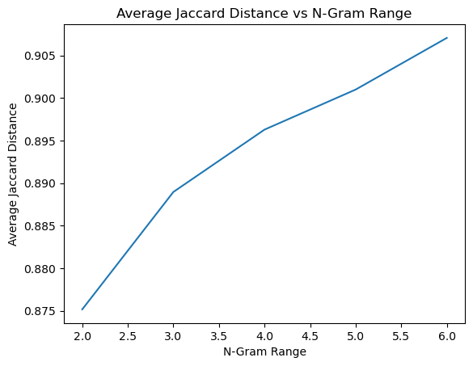

```python
# Apply the clean_text function to the "text" column
news_df['clean_text'] = news_df['text'].apply(lambda x: clean_text(x, "text"))

articles = news_df['clean_text']
ngram_lengths = range(2, 7)

jaccard_dist = []

# Compute Jaccard similarity for each n-gram length and print results
for n in ngram_lengths:
    print(f"Mean Similarity Score using {n}-grams:")
    ngram_sets = [create_ngrams(article, n) for article in articles]
    similarity_matrix = np.zeros((len(articles), len(articles)))
    for i in range(len(articles)):
        for j in range(len(articles)):
            similarity_matrix[i, j] = jaccard_similarity(ngram_sets[i], ngram_sets[j])
    mean_distance = np.mean(similarity_matrix)
    print(mean_distance)
    jaccard_dist.append(mean_distance)

# Plot Jaccard Distance vs n-gram range
plt.plot(ngram_lengths, jaccard_dist)
plt.title('Average Jaccard Distance vs N-Gram Range')
plt.xlabel('N-Gram Range')
plt.ylabel('Average Jaccard Distance')
plt.show()
```

Since the elbow plot does not have a distinct inflection point, we can choose **4 as our ideal n value** as the length of the articles are large and range from 2153 to 99120 and a bigger n value will be help us find similarities between the articles more aptly

```python
news_grams = [create_ngrams(article, 4) for article in articles]
news_similarity_matrix = np.zeros((len(articles), len(articles)))
for i in range(len(articles)):
    for j in range(len(articles)):
        news_similarity_matrix[i, j] = jaccard_similarity(news_grams[i], news_grams[j])

print("News Articles - Jaccard Similarity Score for n=4 : ", np.mean(news_similarity_matrix))
```

```
News Articles - Jaccard Similarity Score for n=4 :  0.8962902464979072
```

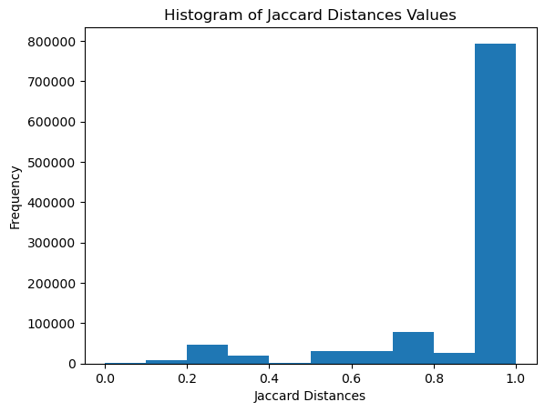

```python
# Plot the distribution of Jaccard Distances
plt.hist(news_similarity_matrix.flatten(), bins=10)
plt.title('Histogram of Jaccard Distances Values')
plt.xlabel('Jaccard Distances')
plt.ylabel('Frequency')
plt.show()
```

From the histogram we can see the spread of Jaccard Distances for n=4 and it is highly likely that ngrams of size 4 will be able to capture the similarity in the news articles irregardless of the fact that majority of the articles are unique and dissimilar. Let us take a look at these similar news articles.

```python
# Get indices of most similar news articles (excluding self-similarity)
np.fill_diagonal(news_similarity_matrix, np.inf) # set diagonal to infinity to exclude self-similarity
indices = np.unravel_index(np.argsort(news_similarity_matrix, axis=None), news_similarity_matrix.shape)
index_pairs = [(indices[0][i], indices[1][i]) for i in range(10)]
```

##### Top 5 most similar news article pairs for n = 4 :

```python
# Print most similar news article pairs and their similarity scores
for i, j in index_pairs[::2]:
    print(f"\nArticle {i}:\n{news_df.loc[i, 'title']}\n")
    print(f"Article {j}:\n{news_df.loc[j, 'title']}\n")
    print(f"Similarity score: {1 - news_similarity_matrix[i, j]}\n")
    print("="*50)
```

```
Article 38:
Toyota Urban Cruiser Car Discount Offers in Kandhamal for March 2022

Article 663:
Toyota Urban Cruiser Car Discount Offers in Kishtwar for March 2022

Similarity score: 0.9865443425076452

==================================================

Article 406:
Toyota Urban Cruiser Car Discount Offers in Madgaon for March 2022

Article 38:
Toyota Urban Cruiser Car Discount Offers in Kandhamal for March 2022

Similarity score: 0.9865443425076452

==================================================

Article 38:
Toyota Urban Cruiser Car Discount Offers in Kandhamal for March 2022

Article 161:
Toyota Urban Cruiser Car Discount Offers in Nirjuli for March 2022

Similarity score: 0.9865443425076452

==================================================

Article 846:
Toyota Urban Cruiser Car Discount Offers in Keonjhar for March 2022

Article 29:
Toyota Urban Cruiser Car Discount Offers in Kulgam for March 2022

Similarity score: 0.9865443425076452

==================================================

Article 39:
Toyota Urban Cruiser Car Discount Offers in Naharlagun for March 2022

Article 38:
Toyota Urban Cruiser Car Discount Offers in Kandhamal for March 2022

Similarity score: 0.9865443425076452

==================================================
```

Since the articles are too long, titles of the top 5 most similar news articles are displayed and we can clearly see that by using **n=4 we were able to capture the similarity between news articles.**

## Similarity in Tweets

```python
tweets_df.shape
```

```
(1020, 6)
```

```python
tweets_df.retweeted.value_counts()
```

```
RT    557
      463
Name: retweeted, dtype: int64
```

```python
tweets_df['text'].nunique()
```

```
788
```

We can observe that around 557 tweets are retweets and there are some duplicates as well. Since retweets are likely to be similar tweets and finding similarity scores on duplicates does not make sense we can drop them before proceeding with finding our n.

```python
# Removing retweets from this analysis
tweets_df=tweets_df[tweets_df.retweeted!='RT']
tweets_df = tweets_df.drop_duplicates(subset=['text']).reset_index(drop=True)
tweets_df.shape
```

```
(461, 6)
```

```python
# Checking lengths of tokens before making any ngrams
print(f"Minimum length of tweets: {len(min(tweets_df['text'], key=len))}")
print(f"Maximum length of tweets: {len(max(tweets_df['text'], key=len))}")
```

```
Minimum length of tweets: 16
Maximum length of tweets: 357
```

```python
tweets_df[['text']].sample(3)
```

|  | text |
| --- | --- |
| 374 | @RaceSimCentral @wanshfr Alain Prost never even did a championship in cars until he was 21 lol (when he won 12 out of 13 races in his debut season in Formula Renault) |
| 395 | Tamiya official international release list May 2022\n\nStatic Models\n 12033 1/12 Renault RE-20 Turbo (w/Photo-Etched Parts)\n 32603 1/48 German Heavy Tank Tiger I Early Production (Eastern Front)\n 2… |
| 19 | @guardiannews On what basis can French Renault justify starting production when so many are withdrawing in protest despite the financial implications to their organisations |

```
Mean Similarity Score using 2-grams:
0.9974620016606026
Mean Similarity Score using 3-grams:
0.9978869655902662
Mean Similarity Score using 4-grams:
0.9979993031990456
Mean Similarity Score using 5-grams:
0.9980939393185713
Mean Similarity Score using 6-grams:
0.9982684064163072
```

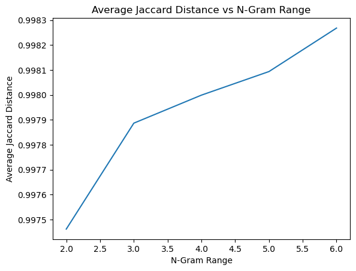

```python
# Apply the clean_text function to the "text" column
tweets_df['clean_text'] = tweets_df['text'].apply(lambda x: clean_text(x, "tweet"))

tweets = tweets_df['clean_text']
ngram_lengths = range(2, 7)

jaccard_dist = []

# Compute Jaccard distance for each n-gram length and print results
for n in ngram_lengths:
    print(f"Mean Similarity Score using {n}-grams:")
    ngram_sets = [create_ngrams(tweet, n) for tweet in tweets]
    similarity_matrix = np.zeros((len(tweets), len(tweets)))
    for i in range(len(tweets)):
        for j in range(len(tweets)):
            similarity_matrix[i, j] = jaccard_similarity(ngram_sets[i], ngram_sets[j])
    mean_distance = np.mean(similarity_matrix)
    print(mean_distance)
    jaccard_dist.append(mean_distance)

# Plot Jaccard Distance vs n-gram range
plt.plot(ngram_lengths, jaccard_dist)
plt.title('Average Jaccard Distance vs N-Gram Range')
plt.xlabel('N-Gram Range')
plt.ylabel('Average Jaccard Distance')
plt.show()
```

In this plot it appears that there is an elbow or “bend” at **n=3**. The elbow plot helps you determine the optimal value of n for n-grams. We can proceed with trigrams for tweets.

```python
trigrams = [create_ngrams(tweet, 3) for tweet in tweets]
tri_similarity_matrix = np.zeros((len(tweets), len(tweets)))
for i in range(len(tweets)):
    for j in range(len(tweets)):
        tri_similarity_matrix[i, j] = jaccard_similarity(trigrams[i], trigrams[j])

print("Tweets - Jaccard Similarity Score for n=3 : ", np.mean(tri_similarity_matrix))
```

```
Tweets - Jaccard Similarity Score for n=3 :  0.9978869655902662
```

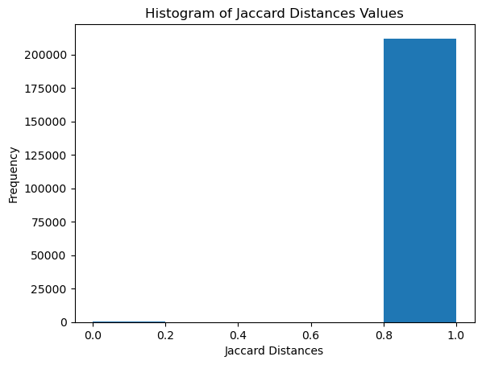

```python
# Plot the distribution of Jaccard Distances
plt.hist(tri_similarity_matrix.flatten(), bins=5)
plt.title('Histogram of Jaccard Distances Values')
plt.xlabel('Jaccard Distances')
plt.ylabel('Frequency')
plt.show()
```

From the histogram we can clearly see that majority of the tweets are dissimalr to each other because we have dropped retweets and duplicates. Hence we can conclude that in our model was able to capture the uniqueness in the tweets data. However, with n=3 let us take a look at the similar tweets in our dataset.

```python
# Get indices of most similar tweets (excluding self-similarity)
np.fill_diagonal(tri_similarity_matrix, np.inf) # set diagonal to infinity to exclude self-similarity
indices = np.unravel_index(np.argsort(tri_similarity_matrix, axis=None), tri_similarity_matrix.shape)
index_pairs = [(indices[0][i], indices[1][i]) for i in range(10)]
```

##### Top 5 most similar tweet pairs for n = 3 :

```python
# Print most similar tweet pairs and their similarity scores
for i, j in index_pairs[::2]:
    print(f"\nTweet {i} Tokens:\n{tweets_df.loc[i, 'clean_text']}")
    print(f"OG Tweet {i}:\n{tweets_df.loc[i, 'text']}\n")
    print(f"Tweet {j} Tokens:\n{tweets_df.loc[j, 'clean_text']}")
    print(f"OG Tweet {j}:\n{tweets_df.loc[j, 'text']}\n")

    print(f"Similarity score: {1 - tri_similarity_matrix[i, j]}\n")
    print("="*50)
```

```
Tweet 168 Tokens:
kiger stunning yet muscular suv stance crafted complement free spirit
OG Tweet 168:
https://t.co/DFfqSVOypZ
Kiger is stunning yet muscular SUV stance is crafted to complement your free spirit.
#renault #cars #nagercoil #Sportysmart #renaultcars #renaultindia #bestcars #buycarsnagercoil #morespacing #renaultkiger https://t.co/LzLJ0IjpyT

Tweet 9 Tokens:
renault kiger stunning yet muscular suv stance crafted complement free spirit
OG Tweet 9:
Renault Kiger is stunning yet muscular SUV stance is crafted to complement your free spirit.
#renault #cars #nagercoil #Sportysmart #renaultcars #renaultindia #bestcars #buycarsnagercoil #morespacing  #renaultkiger https://t.co/0gaRyxca7h

Similarity score: 0.8888888888888888

==================================================

Tweet 423 Tokens:
ya claim worked brand spotify intel amway netflix blizzard sharp canon loewe huawei bentley audi renault oriflame first instagram mask highly valuable game
OG Tweet 423:
@AboxCrypto @socialdudesnft But what can ya claim about @BeaRexOfficial? They worked with such brands as Spotify, Intel, Amway, Netflix, Blizzard, Sharp, Canon, Loewe, Huawei, Bentley, Audi, Renault, Oriflame. And they have the first instagram mask highly valuable game! https://t.co/qFn1mX16CQ

Tweet 41 Tokens:
tell worked brand spotify intel amway netflix blizzard sharp canon loewe huawei bentley audi renault oriflame first instagram mask highly profitable game
OG Tweet 41:
@cz_binance But what can u tell about @BeaRex_io? They worked with such brands as Spotify, Intel, Amway, Netflix, Blizzard, Sharp, Canon, Loewe, Huawei, Bentley, Audi, Renault, Oriflame. And they have the first instagram mask highly profitable game!

Similarity score: 0.7083333333333333

==================================================

Tweet 15 Tokens:
ai anything renault kwid guess
OG Tweet 15:
ai... anything but a renault kwid i guess. https://t.co/vIRj1Cals7

Tweet 173 Tokens:
anything renault kwid
OG Tweet 173:
8. anything but a renault kwid. https://t.co/uzJZyPFCM7
```

[output cut: 19 more lines]

```
Tweet 426 Tokens:
like car renault clio wiliams
OG Tweet 426:
Do you like this car?

Renault Clio Wiliams https://t.co/HoHhM5U6IM

Tweet 224 Tokens:
people want know brand car renault clio diesel cc kw lovely lady
OG Tweet 224:
@KyivIndependent For those people who wants to know the brand of my car: Renault Clio, Diesel, 1400 cc, 66 kW. It is a lovely "lady".

Similarity score: 0.08333333333333337

==================================================
```

Since the tweets contain futile mentions, urls and new line characters, cleaned tweets of the top 5 most similar tweets are displayed and we can clearly see that by **using n=3 we were able to capture the similarity between tweets.**

###### Choosing the right n-grams for News vs Tweets

When analyzing text data using n-grams, the choice of "n" is an important parameter that affects the granularity of the analysis. The choice of "n" determines how many items are included in each n-gram, and this affects the level of detail and context that the n-grams can capture.

The optimal n value was arrived at by plotting and observing the elbow plot. In choosing the value of "n" for n-grams analysis in our case, several factors we considered. One of the most important factors was the length of the tokens. Since the **tweets** ranged from 16 to 357 in length, in order to capture more general patterns in the text we chose a smaller **n = 3**. Whereas, for the **news articles** which had length between 2153 and 99120, using a larger value of "n" would be more appropriate to capture more specific and nuanced patterns in the text and hence we chose **n = 4**.